# hw

Описание задачи

Этот набор данных включает результаты олимпийских участников и их различные характиритстики (например, пол,рост,вес), которые могут оказывать на результат влияние во время выступления.

Постановка задачи

Описание признаков:

Name - имя участника Sex - пол участника Age - возраст участника Height - рост участника Weight - вес участника Team - страна NOC - аббревиатура команды Games - год и время года Year - год игр Season - время года City - город где проводилось соревнование Sport - вид спорта Medal - медаль

1. Считываем данные.

```python
import numpy as np              # Одномерные и многомерные массивы (array)
import pandas as pd             # Таблицы и временные ряды (dataframe, series)
import matplotlib.pyplot as plt # Научная графика
import seaborn as sns           # Еще больше красивой графики для визуализации данных
import sklearn                  # Алгоритмы машинного обучения

url = "https://raw.githubusercontent.com/SawyerYet/ML_Homework/main/athlete_events.csv"
origin_data = pd.read_csv(url)

origin_data.info()
```

```
<class 'pandas.core.frame.DataFrame'>
RangeIndex: 271116 entries, 0 to 271115
Data columns (total 15 columns):
 #   Column  Non-Null Count   Dtype
---  ------  --------------   -----
 0   ID      271116 non-null  int64
 1   Name    271116 non-null  object
 2   Sex     271116 non-null  object
 3   Age     261642 non-null  float64
 4   Height  210945 non-null  float64
 5   Weight  208241 non-null  float64
 6   Team    271116 non-null  object
 7   NOC     271116 non-null  object
 8   Games   271116 non-null  object
 9   Year    271116 non-null  int64
 10  Season  271116 non-null  object
 11  City    271116 non-null  object
 12  Sport   271116 non-null  object
 13  Event   271116 non-null  object
 14  Medal   39783 non-null   object
dtypes: float64(3), int64(2), object(10)
memory usage: 31.0+ MB
```

Первые 5 строк датасета.

```python
origin_data.head(5)
```

|  | ID | Name | Sex | Age | Height | Weight | Team | NOC | Games | Year | Season | City | Sport | Event | Medal |
| --- | --- | --- | --- | --- | --- | --- | --- | --- | --- | --- | --- | --- | --- | --- | --- |
| 0 | 1 | A Dijiang | M | 24.0 | 180.0 | 80.0 | China | CHN | 1992 Summer | 1992 | Summer | Barcelona | Basketball | Basketball Men's Basketball | NaN |
| 1 | 2 | A Lamusi | M | 23.0 | 170.0 | 60.0 | China | CHN | 2012 Summer | 2012 | Summer | London | Judo | Judo Men's Extra-Lightweight | NaN |
| 2 | 3 | Gunnar Nielsen Aaby | M | 24.0 | NaN | NaN | Denmark | DEN | 1920 Summer | 1920 | Summer | Antwerpen | Football | Football Men's Football | NaN |
| 3 | 4 | Edgar Lindenau Aabye | M | 34.0 | NaN | NaN | Denmark/Sweden | DEN | 1900 Summer | 1900 | Summer | Paris | Tug-Of-War | Tug-Of-War Men's Tug-Of-War | Gold |
| 4 | 5 | Christine Jacoba Aaftink | F | 21.0 | 185.0 | 82.0 | Netherlands | NED | 1988 Winter | 1988 | Winter | Calgary | Speed Skating | Speed Skating Women's 500 metres | NaN |

Размеры датасета.

```python
origin_data.shape
```

```
(271116, 15)
```

1. Сменяем признаки типа object на категориальные и выводим основные числовые характеристики

```python
origin_data['Name'] = origin_data['Name'].astype('category')
origin_data['Sex'] = origin_data['Sex'].astype('category')
origin_data['Team'] = origin_data['Team'].astype('category')
origin_data['NOC'] = origin_data['NOC'].astype('category')
origin_data['Games'] = origin_data['Games'].astype('category')
origin_data['Season'] = origin_data['Season'].astype('category')
origin_data['City'] = origin_data['City'].astype('category')
origin_data['Sport'] = origin_data['Sport'].astype('category')
origin_data['Event'] = origin_data['Event'].astype('category')
origin_data['Medal'] = origin_data['Medal'].astype('category')
origin_data.drop(origin_data.columns[[0]], axis = 1, inplace = True)
origin_data.describe(include=['float64'])
```

|  | Age | Height | Weight |
| --- | --- | --- | --- |
| count | 261642.000000 | 210945.000000 | 208241.000000 |
| mean | 25.556898 | 175.338970 | 70.702393 |
| std | 6.393561 | 10.518462 | 14.348020 |
| min | 10.000000 | 127.000000 | 25.000000 |
| 25% | 21.000000 | 168.000000 | 60.000000 |
| 50% | 24.000000 | 175.000000 | 70.000000 |
| 75% | 28.000000 | 183.000000 | 79.000000 |
| max | 97.000000 | 226.000000 | 214.000000 |

min - минимум по какому-либо критерию mean - среднее арифметическое max - максимум по какому-либо критерию std - среднеквадратичное отклонение 25%, 50% , 75% - процент участников, у которых этот критерий меньше числа в таблице.

```python
origin_data.isnull().sum()
```

```
Name           0
Sex            0
Age         9474
Height     60171
Weight     62875
Team           0
NOC            0
Games          0
Year           0
Season         0
City           0
Sport          0
Event          0
Medal     231333
dtype: int64
```

```python
[feature for feature in origin_data.columns if (origin_data[feature].isnull().sum() > 1 and origin_data[feature].isnull().sum() < 60000) ]
```

```
['Age']
```

```python
origin_data.info()
```

```
<class 'pandas.core.frame.DataFrame'>
RangeIndex: 271116 entries, 0 to 271115
Data columns (total 14 columns):
 #   Column  Non-Null Count   Dtype
---  ------  --------------   -----
 0   Name    271116 non-null  category
 1   Sex     271116 non-null  category
 2   Age     261642 non-null  float64
 3   Height  210945 non-null  float64
 4   Weight  208241 non-null  float64
 5   Team    271116 non-null  category
 6   NOC     271116 non-null  category
 7   Games   271116 non-null  category
 8   Year    271116 non-null  int64
 9   Season  271116 non-null  category
 10  City    271116 non-null  category
 11  Sport   271116 non-null  category
 12  Event   271116 non-null  category
 13  Medal   39783 non-null   category
dtypes: category(10), float64(3), int64(1)
memory usage: 17.5 MB
```

1. Выведем количество полученных каждой медали.

```python
origin_data['Medal'].value_counts()
```

```
Medal
Gold      13372
Bronze    13295
Silver    13116
Name: count, dtype: int64
```

Построим матрицу карреляции по числовым признакам.

```python
corrMatrix = origin_data.select_dtypes(include=['float64']).corr()
corrMatrix.style.background_gradient(cmap='coolwarm', vmin=-1, vmax=1)
```

|  | Age | Height | Weight |
| --- | --- | --- | --- |
| Age | 1.000000 | 0.138246 | 0.212069 |
| Height | 0.138246 | 1.000000 | 0.796213 |
| Weight | 0.212069 | 0.796213 | 1.000000 |

По полученным данным сложно сделать какие-то выводы. Выведем информацию о категориальных признаках

```python
origin_data.describe(include=['category'])
```

|  | Name | Sex | Team | NOC | Games | Season | City | Sport | Event | Medal |
| --- | --- | --- | --- | --- | --- | --- | --- | --- | --- | --- |
| count | 271116 | 271116 | 271116 | 271116 | 271116 | 271116 | 271116 | 271116 | 271116 | 39783 |
| unique | 134732 | 2 | 1184 | 230 | 51 | 2 | 42 | 66 | 765 | 3 |
| top | Robert Tait McKenzie | M | United States | USA | 2000 Summer | Summer | London | Athletics | Football Men's Football | Gold |
| freq | 58 | 196594 | 17847 | 18853 | 13821 | 222552 | 22426 | 38624 | 5733 | 13372 |

Визуализируем данные

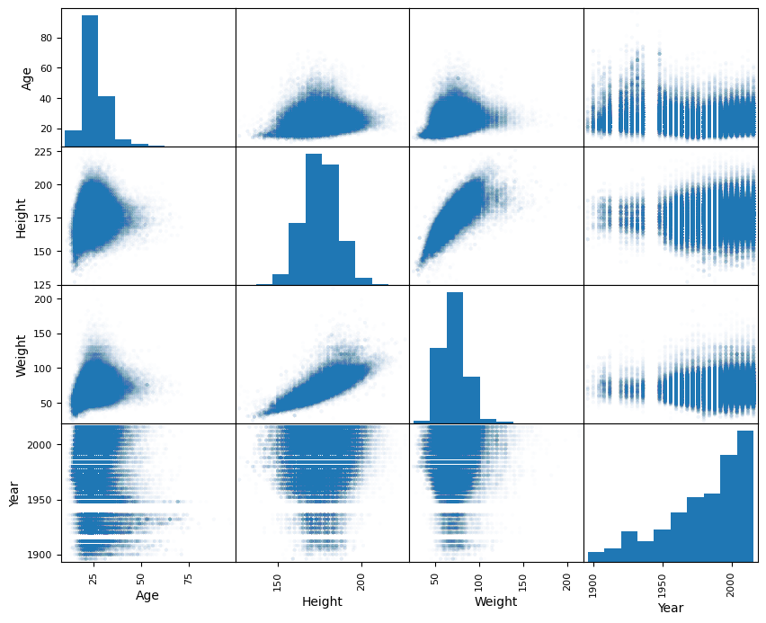

```python
pd.plotting.scatter_matrix(origin_data, figsize = (10, 8),alpha=.01)
pass
```

Что-то из этого понять сложно.

1. В нормализации данных, в моем датасете нет смысла.
2. Разобьем данные на тестовую и обучающую выборку. Разобьем данные на обучающую и тестовую выборки в пропорции 3:1 (75% - обучающая выборка, 25% - тестовая) Будем использовать все входные признаки кроме City.

```python
X = origin_data.drop(['City'], axis=1)
y = origin_data['City']
```

```python
from sklearn.model_selection import train_test_split
X_train, X_test, y_train, y_test = train_test_split(X, y, test_size = 0.25, random_state = 42)

N_train, _ = X_train.shape
N_test,  _ = X_test.shape

N_train, N_test
```

```
(203337, 67779)
```